# 501 MLR Model

```r
workModelSeville1 <- lm(energy_demand ~ E_1 + E_2 + E_25 + temp + humidity + pressure + wind_speed + rain_duration + factor(day_night) + factor(time_band) + factor(season) + factor(weather_main), data = workSeville)
```

```r
vif(workModelSeville1)
```

```
##                           GVIF Df GVIF^(1/(2*Df))
## E_1                  14.477427  1        3.804921
## E_2                  12.448458  1        3.528237
## E_25                  2.162420  1        1.470517
## temp                  3.784144  1        1.945288
## humidity              2.931415  1        1.712138
## pressure              1.604205  1        1.266572
## wind_speed            1.210197  1        1.100089
## rain_duration         2.059981  1        1.435263
## factor(day_night)     1.928208  1        1.388599
## factor(time_band)     1.116888  2        1.028022
## factor(season)        2.801229  3        1.187294
## factor(weather_main)  2.926601 10        1.055160
```

```r
workModelSevilleFull <- lm(energy_demand ~ E_1 + E_25 + temp + humidity + pressure + wind_speed + rain_duration + factor(day_night) + factor(time_band) + factor(season) + factor(weather_main), data = workSeville)
vif(workModelSevilleFull)
```

```
##                          GVIF Df GVIF^(1/(2*Df))
## E_1                  2.048562  1        1.431280
## E_25                 1.994263  1        1.412184
## temp                 3.726333  1        1.930371
## humidity             2.924283  1        1.710053
## pressure             1.596200  1        1.263408
## wind_speed           1.195560  1        1.093417
## rain_duration        2.059975  1        1.435261
## factor(day_night)    1.833637  1        1.354119
## factor(time_band)    1.113687  2        1.027285
## factor(season)       2.762347  3        1.184531
## factor(weather_main) 2.912232 10        1.054900
```

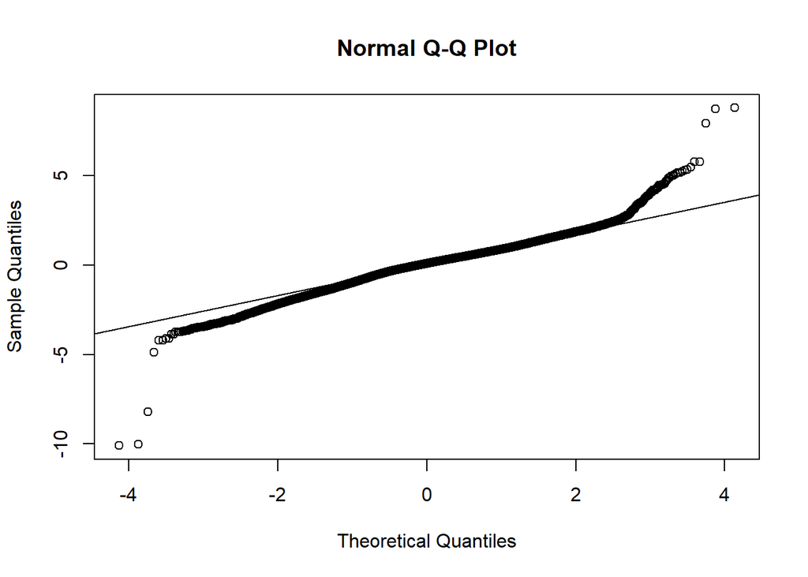

```r
# to obtain residuals
res.fullmodel1 <- residuals(workModelSevilleFull)
# to obtain standardized residuals
std.res.fullmodel1 <- rstandard(workModelSevilleFull)
# to obtain fitted/predicted values
pred.fullmodel1 <- fitted.values(workModelSevilleFull)
par(mfrow=c(1,1))
qqnorm(y = std.res.fullmodel1, main = " Normal Q-Q Plot ",
       xlab = "Theoretical Quantiles", ylab = "Sample Quantiles")
qqline(y = std.res.fullmodel1)
```

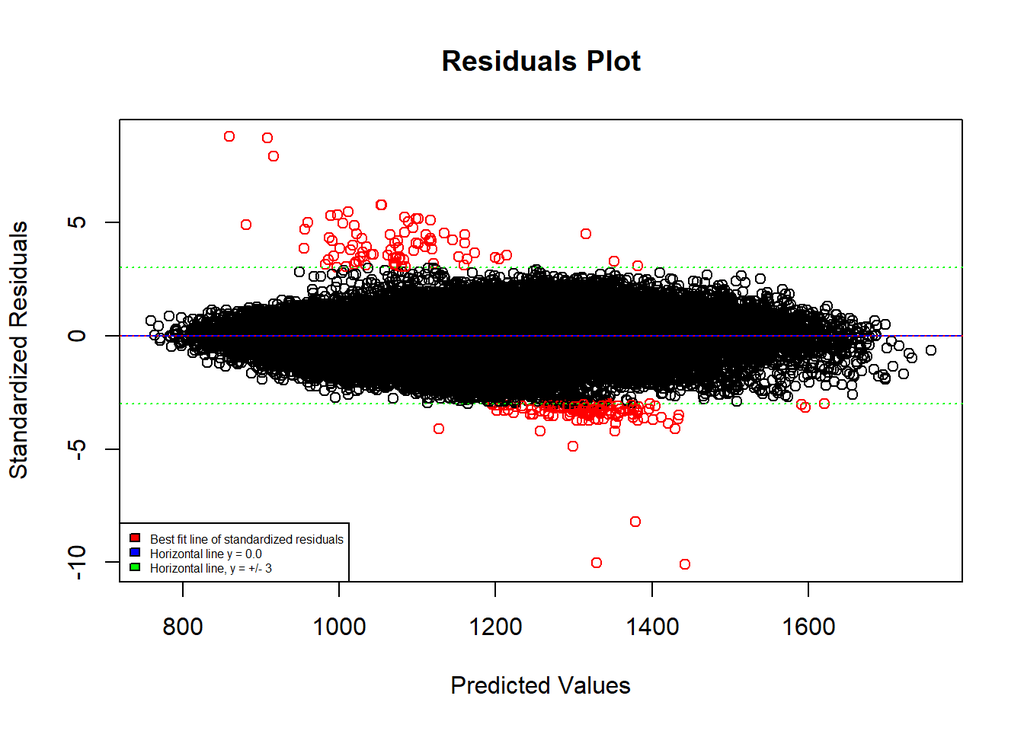

```r
#residual plot
resplotdata1 <- data.frame(std.res.fullmodel1, pred.fullmodel1)
resbf1 <- lm(std.res.fullmodel1 ~ pred.fullmodel1, data = resplotdata1)
plot(x = pred.fullmodel1, y = std.res.fullmodel1, ylab = "Standardized Residuals", xlab = "Predicted Values", main = "Residuals Plot", col = ifelse(std.res.fullmodel1 < -3,"red",ifelse(std.res.fullmodel1 > 3,"red","black")))
abline(h = 0, col="blue", lty=1)
abline(resbf1, col="red", lty=3)
abline(h = 3, col="green", lty=3)
abline(h=-3, col="green", lty=3)
legend("bottomleft", legend=c("Best fit line of standardized residuals", "Horizontal line y = 0.0", "Horizontal line, y = +/- 3"), fill = c("red","blue","green"), cex = 0.5)
```

```r
summary(workModelSevilleFull)
```

```
##
## Call:
## lm(formula = energy_demand ~ E_1 + E_25 + temp + humidity + pressure +
##     wind_speed + rain_duration + factor(day_night) + factor(time_band) +
##     factor(season) + factor(weather_main), data = workSeville)
##
## Residuals:
##     Min      1Q  Median      3Q     Max
## -549.95  -30.21    4.87   33.75  478.29
##
## Coefficients:
##                           Estimate  Std. Error t value             Pr(>|t|)
## (Intercept)            -932.840821   68.808830 -13.557 < 0.0000000000000002 ***
## E_1                       0.890426    0.002422 367.692 < 0.0000000000000002 ***
## E_25                      0.111392    0.002398  46.461 < 0.0000000000000002 ***
## temp                      1.515006    0.077855  19.459 < 0.0000000000000002 ***
## humidity                 -0.355891    0.024362 -14.608 < 0.0000000000000002 ***
## pressure                  0.483766    0.060212   8.034 0.000000000000000977 ***
## wind_speed                2.987490    0.190422  15.689 < 0.0000000000000002 ***
## rain_duration             3.732190    2.169563   1.720             0.085398 .
## factor(day_night)2       26.545740    0.882968  30.064 < 0.0000000000000002 ***
## factor(time_band)2       -2.706043    4.383971  -0.617             0.537069
## factor(time_band)3       25.388655    3.414551   7.435 0.000000000000107216 ***
## factor(season)2         -17.569908    1.092649 -16.080 < 0.0000000000000002 ***
## factor(season)3          -5.339033    0.962640  -5.546 0.000000029451488123 ***
## factor(season)4           6.990646    1.115924   6.264 0.000000000379592466 ***
## factor(weather_main)2     2.242919    0.892504   2.513             0.011974 *
## factor(weather_main)3   -12.318180    4.275098  -2.881             0.003962 **
## factor(weather_main)4   -14.457822    3.478341  -4.157 0.000032408148010205 ***
## factor(weather_main)5   -15.316699    3.093864  -4.951 0.000000743884166897 ***
## factor(weather_main)6   -35.864988    3.428151 -10.462 < 0.0000000000000002 ***
## factor(weather_main)7    -7.805466    2.448502  -3.188             0.001435 **
## factor(weather_main)8     4.944984    2.054759   2.407             0.016108 *
## factor(weather_main)9    41.459354   11.394392   3.639             0.000275 ***
## factor(weather_main)11   26.081350   54.527770   0.478             0.632431
## factor(weather_main)12    7.346205    5.619242   1.307             0.191111
## ---
## Signif. codes:  0 '***' 0.001 '**' 0.01 '*' 0.05 '.' 0.1 ' ' 1
##
## Residual standard error: 54.52 on 27976 degrees of freedom
## Multiple R-squared:   0.92,  Adjusted R-squared:  0.9199
## F-statistic: 1.399e+04 on 23 and 27976 DF,  p-value: < 0.00000000000000022
```

```r
df<- workModelSevilleFull %>%
  tidy()
#Get the variables which there p-value larger than 0.05
df%>%
  filter(df$p.value>0.05)
```

| term | estimate | std.error | statistic | p.value |
| --- | --- | --- | --- | --- |
| rain_duration | 3.732190 | 2.169563 | 1.7202496 | 0.08539813 |
| factor(time_band)2 | -2.706043 | 4.383971 | -0.6172585 | 0.53706929 |
| factor(weather_main)11 | 26.081350 | 54.527770 | 0.4783132 | 0.63243107 |
| factor(weather_main)12 | 7.346205 | 5.619242 | 1.3073303 | 0.19111131 |

```r
workModelSevillePvalue <- lm(energy_demand ~ E_1 + E_25 + temp + humidity + pressure + wind_speed + factor(day_night) + factor(time_band) + factor(season) + factor(weather_main), data = workSeville)
summary(workModelSevillePvalue)
```

```
##
## Call:
## lm(formula = energy_demand ~ E_1 + E_25 + temp + humidity + pressure +
##     wind_speed + factor(day_night) + factor(time_band) + factor(season) +
##     factor(weather_main), data = workSeville)
##
## Residuals:
##     Min      1Q  Median      3Q     Max
## -549.95  -30.16    4.88   33.74  478.28
##
## Coefficients:
##                           Estimate  Std. Error t value             Pr(>|t|)
## (Intercept)            -926.766568   68.720577 -13.486 < 0.0000000000000002 ***
## E_1                       0.890376    0.002422 367.685 < 0.0000000000000002 ***
## E_25                      0.111475    0.002397  46.503 < 0.0000000000000002 ***
## temp                      1.513449    0.077853  19.440 < 0.0000000000000002 ***
## humidity                 -0.354561    0.024351 -14.561 < 0.0000000000000002 ***
## pressure                  0.478155    0.060126   7.953  0.00000000000000189 ***
## wind_speed                2.994190    0.190388  15.727 < 0.0000000000000002 ***
## factor(day_night)2       26.504162    0.882668  30.027 < 0.0000000000000002 ***
## factor(time_band)2       -2.815274    4.383665  -0.642             0.520736
## factor(time_band)3       25.368138    3.414650   7.429  0.00000000000011237 ***
## factor(season)2         -17.582847    1.092661 -16.092 < 0.0000000000000002 ***
## factor(season)3          -5.340872    0.962673  -5.548  0.00000002916363891 ***
## factor(season)4           6.970419    1.115901   6.246  0.00000000042592646 ***
## factor(weather_main)2     2.210683    0.892339   2.477             0.013240 *
## factor(weather_main)3   -11.990918    4.271012  -2.808             0.004996 **
## factor(weather_main)4   -14.479694    3.478440  -4.163  0.00003154496399759 ***
## factor(weather_main)5   -15.332309    3.093959  -4.956  0.00000072541913847 ***
## factor(weather_main)6   -35.873529    3.428268 -10.464 < 0.0000000000000002 ***
## factor(weather_main)7    -7.783363    2.448554  -3.179             0.001481 **
## factor(weather_main)8     7.245024    1.560299   4.643  0.00000344352885666 ***
## factor(weather_main)9    41.439988   11.394785   3.637             0.000277 ***
## factor(weather_main)11   26.078549   54.529679   0.478             0.632480
## factor(weather_main)12    8.050709    5.604495   1.436             0.150879
## ---
## Signif. codes:  0 '***' 0.001 '**' 0.01 '*' 0.05 '.' 0.1 ' ' 1
##
## Residual standard error: 54.52 on 27977 degrees of freedom
## Multiple R-squared:   0.92,  Adjusted R-squared:  0.9199
## F-statistic: 1.462e+04 on 22 and 27977 DF,  p-value: < 0.00000000000000022
```

- p-value approach

```r
anova(workModelSevillePvalue, workModelSevilleFull)
```

|  | Res.Df | RSS | Df | Sum of Sq | F | Pr(>F) |
| --- | --- | --- | --- | --- | --- | --- |
| 1 | 27977 | 83169196 | NA | NA | NA | NA |
| 2 | 27976 | 83160400 | 1 | 8796.581 | 2.959259 | 0.08539813 |

- Best subset selection method

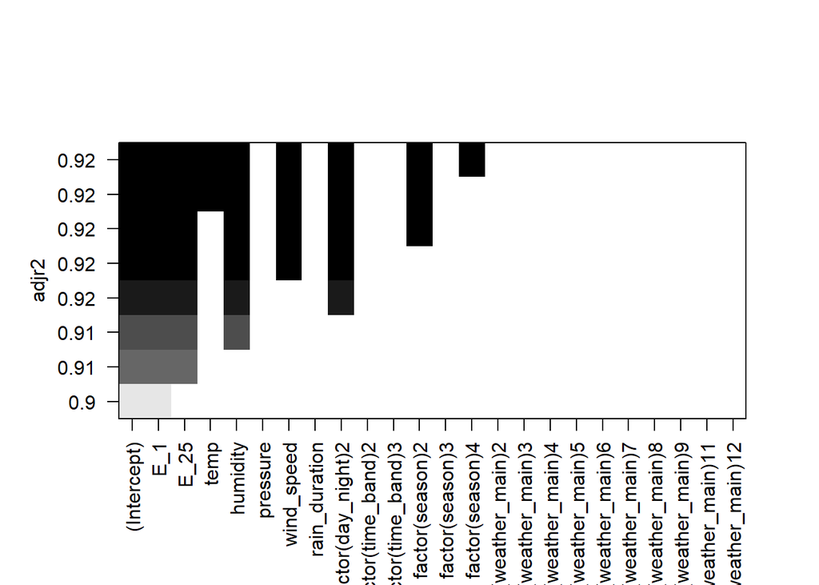

```r
bestfits <- regsubsets(energy_demand ~ E_1 + E_25 + temp + humidity + pressure + wind_speed + rain_duration + factor(day_night) + factor(time_band) + factor(season) + factor(weather_main), data = workSeville, nbest = 1)
plot(bestfits, scale="adjr2")
```

```r
workModelSevilleBestfit<-lm(energy_demand ~ E_1 + E_25 + temp + humidity + wind_speed + factor(day_night) + factor(season) , data = workSeville)
summary(workModelSevilleBestfit)
```

```
##
## Call:
## lm(formula = energy_demand ~ E_1 + E_25 + temp + humidity + wind_speed +
##     factor(day_night) + factor(season), data = workSeville)
##
## Residuals:
##     Min      1Q  Median      3Q     Max
## -548.84  -30.38    5.07   33.74  477.84
##
## Coefficients:
##                       Estimate  Std. Error t value             Pr(>|t|)
## (Intercept)        -393.271898   23.487782 -16.744 < 0.0000000000000002 ***
## E_1                   0.890138    0.002426 366.882 < 0.0000000000000002 ***
## E_25                  0.113507    0.002400  47.294 < 0.0000000000000002 ***
## temp                  1.352323    0.076360  17.710 < 0.0000000000000002 ***
## humidity             -0.377995    0.022132 -17.079 < 0.0000000000000002 ***
## wind_speed            3.012031    0.182150  16.536 < 0.0000000000000002 ***
## factor(day_night)2   25.972373    0.870245  29.845 < 0.0000000000000002 ***
## factor(season)2     -18.083837    1.077474 -16.784 < 0.0000000000000002 ***
## factor(season)3      -4.877645    0.960503  -5.078          0.000000383 ***
## factor(season)4       9.565773    1.029338   9.293 < 0.0000000000000002 ***
## ---
## Signif. codes:  0 '***' 0.001 '**' 0.01 '*' 0.05 '.' 0.1 ' ' 1
##
## Residual standard error: 54.85 on 27990 degrees of freedom
## Multiple R-squared:  0.919,  Adjusted R-squared:  0.9189
## F-statistic: 3.527e+04 on 9 and 27990 DF,  p-value: < 0.00000000000000022
```

```r
anova(workModelSevilleBestfit, workModelSevillePvalue)
```

|  | Res.Df | RSS | Df | Sum of Sq | F | Pr(>F) |
| --- | --- | --- | --- | --- | --- | --- |
| 1 | 27990 | 84221007 | NA | NA | NA | NA |
| 2 | 27977 | 83169196 | 13 | 1051811 | 27.21654 | 0.0000000000000000000000000000000000000000000000000000000000000000003462236 |

- AIC with forward selection approach test method

```r
workNullModel<- lm(energy_demand ~ 1, data = workSeville)
step.working <- stepAIC(workNullModel, scope = list(lower = workNullModel,
upper = workModelSevilleFull), direction = "forward", trace=FALSE)
summary(step.working)
```

```
##
## Call:
## lm(formula = energy_demand ~ E_1 + E_25 + humidity + factor(day_night) +
##     wind_speed + factor(season) + temp + factor(weather_main) +
##     pressure + factor(time_band) + rain_duration, data = workSeville)
##
## Residuals:
##     Min      1Q  Median      3Q     Max
## -549.95  -30.21    4.87   33.75  478.29
##
## Coefficients:
##                           Estimate  Std. Error t value             Pr(>|t|)
## (Intercept)            -932.840821   68.808830 -13.557 < 0.0000000000000002 ***
## E_1                       0.890426    0.002422 367.692 < 0.0000000000000002 ***
## E_25                      0.111392    0.002398  46.461 < 0.0000000000000002 ***
## humidity                 -0.355891    0.024362 -14.608 < 0.0000000000000002 ***
## factor(day_night)2       26.545740    0.882968  30.064 < 0.0000000000000002 ***
## wind_speed                2.987490    0.190422  15.689 < 0.0000000000000002 ***
## factor(season)2         -17.569908    1.092649 -16.080 < 0.0000000000000002 ***
## factor(season)3          -5.339033    0.962640  -5.546 0.000000029451488123 ***
## factor(season)4           6.990646    1.115924   6.264 0.000000000379592466 ***
## temp                      1.515006    0.077855  19.459 < 0.0000000000000002 ***
## factor(weather_main)2     2.242919    0.892504   2.513             0.011974 *
## factor(weather_main)3   -12.318180    4.275098  -2.881             0.003962 **
## factor(weather_main)4   -14.457822    3.478341  -4.157 0.000032408148010200 ***
## factor(weather_main)5   -15.316699    3.093864  -4.951 0.000000743884166896 ***
## factor(weather_main)6   -35.864988    3.428151 -10.462 < 0.0000000000000002 ***
## factor(weather_main)7    -7.805466    2.448502  -3.188             0.001435 **
## factor(weather_main)8     4.944984    2.054759   2.407             0.016108 *
## factor(weather_main)9    41.459354   11.394392   3.639             0.000275 ***
## factor(weather_main)11   26.081350   54.527770   0.478             0.632431
## factor(weather_main)12    7.346205    5.619242   1.307             0.191111
## pressure                  0.483766    0.060212   8.034 0.000000000000000977 ***
## factor(time_band)2       -2.706043    4.383971  -0.617             0.537069
## factor(time_band)3       25.388655    3.414551   7.435 0.000000000000107216 ***
## rain_duration             3.732190    2.169563   1.720             0.085398 .
## ---
## Signif. codes:  0 '***' 0.001 '**' 0.01 '*' 0.05 '.' 0.1 ' ' 1
##
## Residual standard error: 54.52 on 27976 degrees of freedom
## Multiple R-squared:   0.92,  Adjusted R-squared:  0.9199
## F-statistic: 1.399e+04 on 23 and 27976 DF,  p-value: < 0.00000000000000022
```

- Cross Validation test method

```r
# Set seed for reproducibility in CV
set.seed(123)
# Set up repeated k-fold cross-validation, with k=10
train.control <- trainControl(method = "cv", number = 10)
# Train the model
step.cv.work <- train(energy_demand ~ E_1 + E_25 + temp + humidity + pressure + wind_speed + rain_duration + factor(day_night) + factor(time_band) + factor(season) + factor(weather_main), data = workSeville, method = "leapBackward",
tuneGrid = data.frame(nvmax = 1:11),
trControl = train.control)
```

```
## Reordering variables and trying again:
```

```r
step.cv.work$results
```

|  | nvmax | RMSE | Rsquared | MAE | RMSESD | RsquaredSD | MAESD |
| --- | --- | --- | --- | --- | --- | --- | --- |
| 1 | 1 | 59.57573 | 0.9043975 | 44.57939 | 1.221917 | 0.004244345 | 0.6423323 |
| 2 | 2 | 57.09586 | 0.9121760 | 43.66011 | 1.133316 | 0.003966191 | 0.4249399 |
| 3 | 3 | 56.33892 | 0.9144816 | 42.93167 | 1.171180 | 0.004016033 | 0.4516895 |
| 4 | 4 | 55.66275 | 0.9165231 | 42.41797 | 1.199483 | 0.004012566 | 0.4875560 |
| 5 | 5 | 55.33250 | 0.9175097 | 42.08566 | 1.261075 | 0.004200302 | 0.5118801 |
| 6 | 6 | 55.18585 | 0.9179515 | 41.92576 | 1.240132 | 0.004116422 | 0.4772417 |
| 7 | 7 | 55.02241 | 0.9184339 | 41.80915 | 1.234701 | 0.004054649 | 0.4572180 |
| 8 | 8 | 54.89544 | 0.9188115 | 41.69207 | 1.234112 | 0.004038689 | 0.4604791 |
| 9 | 9 | 54.78709 | 0.9191341 | 41.58748 | 1.236069 | 0.004002919 | 0.4402662 |
| 10 | 10 | 54.71329 | 0.9193521 | 41.55636 | 1.234351 | 0.003989161 | 0.4254618 |

[output cut: 1 more lines]

```r
summary(step.cv.work$finalModel)
```

```
## Subset selection object
## 23 Variables  (and intercept)
##                        Forced in Forced out
## E_1                        FALSE      FALSE
## E_25                       FALSE      FALSE
## temp                       FALSE      FALSE
## humidity                   FALSE      FALSE
## pressure                   FALSE      FALSE
## wind_speed                 FALSE      FALSE
## rain_duration              FALSE      FALSE
## factor(day_night)2         FALSE      FALSE
## factor(time_band)2         FALSE      FALSE
## factor(time_band)3         FALSE      FALSE
## factor(season)2            FALSE      FALSE
## factor(season)3            FALSE      FALSE
## factor(season)4            FALSE      FALSE
## factor(weather_main)2      FALSE      FALSE
## factor(weather_main)3      FALSE      FALSE
## factor(weather_main)4      FALSE      FALSE
## factor(weather_main)5      FALSE      FALSE
## factor(weather_main)6      FALSE      FALSE
## factor(weather_main)7      FALSE      FALSE
## factor(weather_main)8      FALSE      FALSE
## factor(weather_main)9      FALSE      FALSE
## factor(weather_main)11     FALSE      FALSE
## factor(weather_main)12     FALSE      FALSE
## 1 subsets of each size up to 11
## Selection Algorithm: backward
##           E_1 E_25 temp humidity pressure wind_speed rain_duration
## 1  ( 1 )  "*" " "  " "  " "      " "      " "        " "
## 2  ( 1 )  "*" "*"  " "  " "      " "      " "        " "
## 3  ( 1 )  "*" "*"  " "  "*"      " "      " "        " "
## 4  ( 1 )  "*" "*"  " "  "*"      " "      " "        " "
## 5  ( 1 )  "*" "*"  " "  "*"      " "      "*"        " "
## 6  ( 1 )  "*" "*"  " "  "*"      " "      "*"        " "
## 7  ( 1 )  "*" "*"  "*"  "*"      " "      "*"        " "
## 8  ( 1 )  "*" "*"  "*"  "*"      " "      "*"        " "
## 9  ( 1 )  "*" "*"  "*"  "*"      " "      "*"        " "
## 10  ( 1 ) "*" "*"  "*"  "*"      " "      "*"        " "
## 11  ( 1 ) "*" "*"  "*"  "*"      "*"      "*"        " "
```

[output cut: 45 more lines]

```
## 9  ( 1 )  "*"                   " "                   " "
## 10  ( 1 ) "*"                   " "                   " "
## 11  ( 1 ) "*"                   " "                   " "
##           factor(weather_main)9 factor(weather_main)11 factor(weather_main)12
## 1  ( 1 )  " "                   " "                    " "
## 2  ( 1 )  " "                   " "                    " "
## 3  ( 1 )  " "                   " "                    " "
## 4  ( 1 )  " "                   " "                    " "
## 5  ( 1 )  " "                   " "                    " "
## 6  ( 1 )  " "                   " "                    " "
## 7  ( 1 )  " "                   " "                    " "
## 8  ( 1 )  " "                   " "                    " "
## 9  ( 1 )  " "                   " "                    " "
## 10  ( 1 ) " "                   " "                    " "
## 11  ( 1 ) " "                   " "                    " "
```

## Select the final model

Final model is the workModelSevillePvalue with highest Adjusted R-square.

### Build the Final Model

```r
workFinal <- workModelSevillePvalue
```

### Check the linearity, heteroscedasticity, outlier and normal assumption

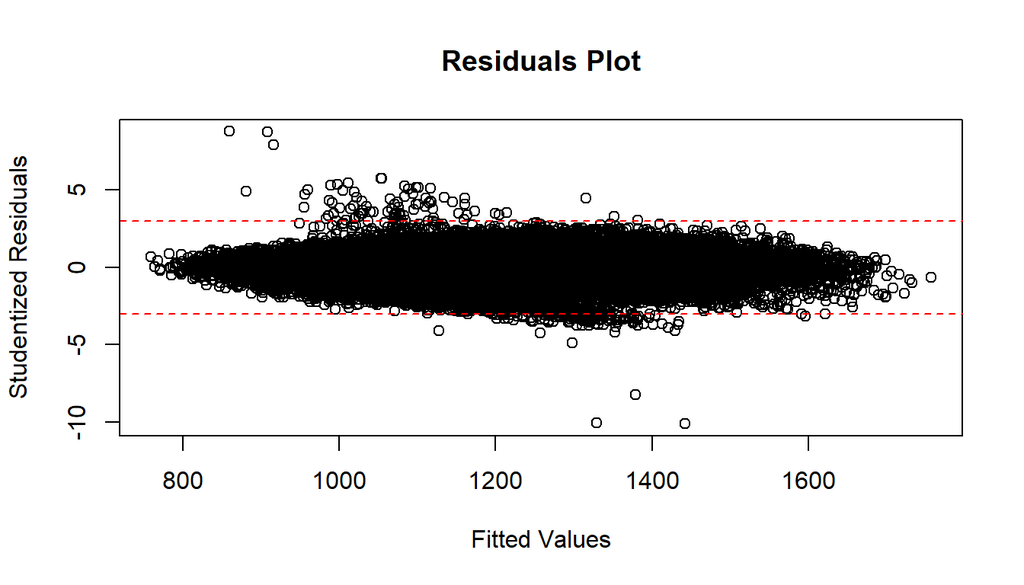

```r
par(mfrow=c(1,1))
#Residual Plot
plot(x=fitted(workFinal), y=studres(workFinal), xlab = "Fitted Values",
ylab = "Studentized Residuals", main='Residuals Plot')
abline(h=-3, col="red", lty=2)
abline(h=3, col="red", lty=2)
```

```r
#norm test
std.res <- rstandard(workFinal)
ad.test(std.res)
```

```
##
##  Anderson-Darling normality test
##
## data:  std.res
## A = 131.25, p-value < 0.00000000000000022
```

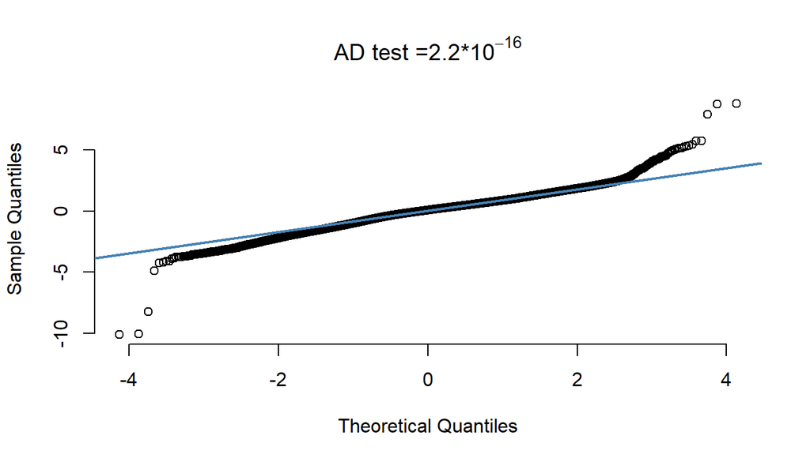

```r
qqnorm(studres(workFinal), pch = 1, frame = FALSE, main=expression("AD test =2.2*10"^-16))
qqline(studres(workFinal), col = "steelblue", lwd = 2)
```

```r
#leverage
lev<-hatvalues(workFinal)
cutlev = (2*length(coefficients(workFinal)))/nrow(workSeville)
# Count and assess the number of leverage values > cut-off
potoutlier <- sum(lev > cutlev, na.rm=TRUE)
totcount = length(fitted(workFinal))
print(paste("The number of leverage points that are potential outliers is", potoutlier,".  This is", round(100*potoutlier/totcount,2),"% of the total number of predicted values, (", totcount,") thus not material."))
```

```
## [1] "The number of leverage points that are potential outliers is 2134 .  This is 7.62 % of the total number of predicted values, ( 28000 ) thus not material."
```

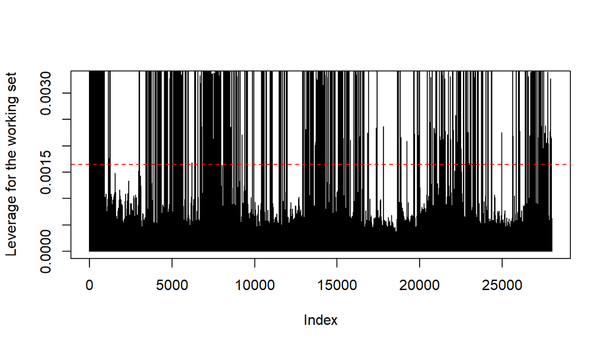

```r
#barplot(lev, ylim = c(0, 2*cutlev))
plot(lev, type="h", ylim = c(0, 2*cutlev), ylab="Leverage for the working set")
abline(h = cutlev, col = "red", lty=2)
```

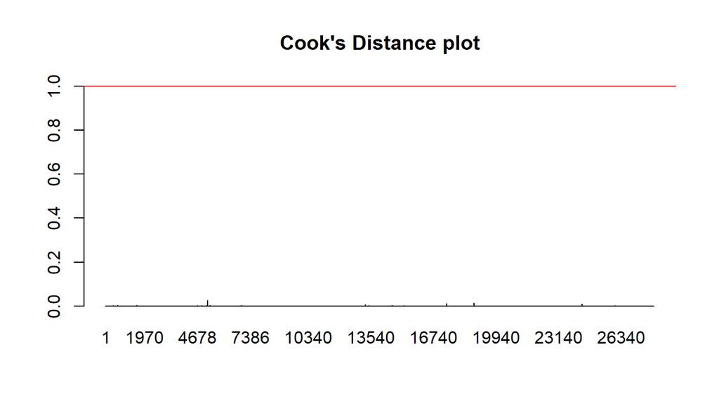

```r
#cook distance
cookdist<-cooks.distance(workFinal)
barplot(cookdist, ylim=c(0,1.01), main = "Cook's Distance plot")
abline(h = 1, col = "red")
```

### Use the estimated model to predict the values in the evaluation set

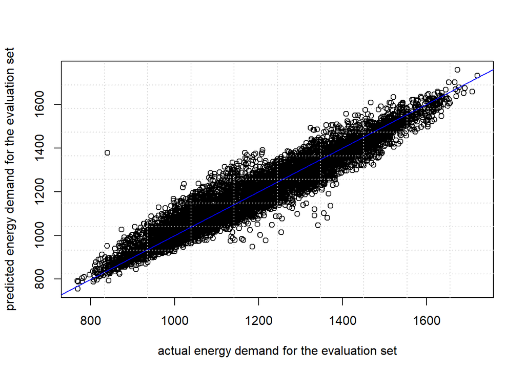

```r
newdata <- evalSeville[ c(-2,-13)]
predict.eval <- predict(workFinal, newdata)
plot(x = evalSeville$energy_demand, y=predict.eval, xlab="actual energy demand for the evaluation set",
ylab="predicted energy demand for the evaluation set")
abline(a=0, b=1, col="blue")
grid(10,10)
```

### Compute the RMSE for the predictions

```r
rootmse <- rmse(evalSeville$energy_demand, predict.eval)
print(paste("The root mean square error of the predicted vs actual",nrow(evalSeville),"hourly energy_data points for Seville over the 2015-2018 timespan is an energy demand difference of",round(rootmse,2),"kW (assumed unit of measure)."))
```

```
## [1] "The root mean square error of the predicted vs actual 7001 hourly energy_data points for Seville over the 2015-2018 timespan is an energy demand difference of 54.39 kW (assumed unit of measure)."
```

```r
diffpct <- c((abs(evalSeville$energy_demand - predict.eval))/evalSeville$energy_demand)
print(paste("The mean difference between the",nrow(evalSeville),"evaluation data set actual and model predicted values is",round(100*mean(diffpct),2),"%."))
```

```
## [1] "The mean difference between the 7001 evaluation data set actual and model predicted values is 3.49 %."
```

## Valencia Model

```r
evaldata<-read.csv('data\\evaluation_Valencia.csv')
workdata<-read.csv('data\\working_Valencia.csv')
#remove index and time_ID columns from "eval" analysis dataframe
evalValencia<-evaldata[c(-1,-2)]
#remove index and time_ID columns from "work" analysis dataframe
workValencia<-workdata[c(-1,-2)]
head(workValencia, 4L)
```

|  | E_1 | E_2 | E_25 | temp | humidity | pressure | wind_speed | rain_duration | snow_duration | day_night | time_band | season | weather_main | energy_demand |
| --- | --- | --- | --- | --- | --- | --- | --- | --- | --- | --- | --- | --- | --- | --- |
| 1 | 1359.453 | 1109.831 | 1256.750 | 270.475 | 77 | 1001 | 1 | 0 | 0 | 2 | 1 | 4 | 1 | 1415.377 |
| 2 | 1115.686 | 1136.149 | 1230.321 | 270.292 | 71 | 1004 | 2 | 0 | 0 | 2 | 1 | 4 | 1 | 1109.831 |
| 3 | 1136.149 | 1120.369 | 1241.974 | 270.292 | 71 | 1004 | 2 | 0 | 0 | 2 | 1 | 4 | 1 | 1115.686 |
| 4 | 1120.369 | 1150.645 | 1283.792 | 270.292 | 71 | 1004 | 2 | 0 | 0 | 2 | 1 | 4 | 1 | 1136.149 |

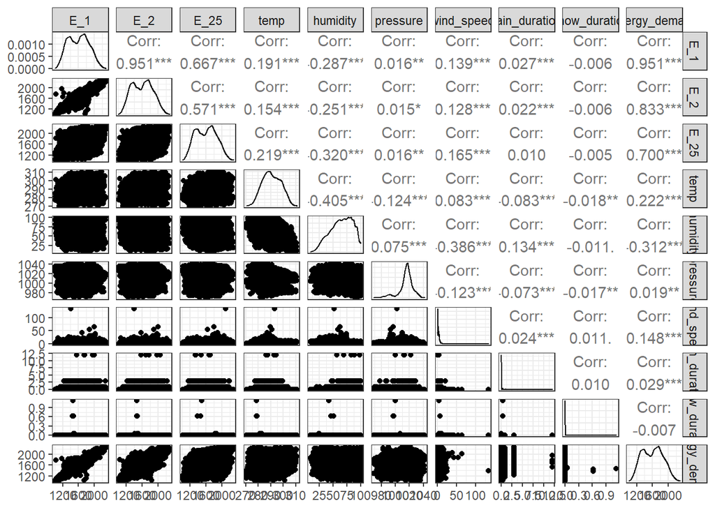

```r
# Correlation matrix for numeric predictors only (categorical predictors excluded)
workcor<-workValencia[c(-10:-13) ]
ggpairs(workcor)
```

```r
cor(workValencia)
```

```
##                        E_1          E_2         E_25        temp    humidity
## E_1            1.000000000  0.951054128  0.666939844  0.19109473 -0.28730452
## E_2            0.951054128  1.000000000  0.571164357  0.15367732 -0.25124085
## E_25           0.666939844  0.571164357  1.000000000  0.21893597 -0.31975014
## temp           0.191094734  0.153677316  0.218935967  1.00000000 -0.40538712
## humidity      -0.287304516 -0.251240855 -0.319750141 -0.40538712  1.00000000
## pressure       0.016279401  0.015299073  0.015840152 -0.12401369  0.07482097
## wind_speed     0.138722130  0.127877981  0.165160263  0.08321668 -0.38567524
## rain_duration  0.026806148  0.022081323  0.009561392 -0.08286733  0.13416410
## snow_duration -0.005782161 -0.005757167 -0.005214940 -0.01752449 -0.01128094
## day_night     -0.542546338 -0.535040922 -0.511806591 -0.38474840  0.44420938
## time_band      0.110986153  0.091678654  0.113058687 -0.13846625 -0.01513187
## season         0.078852572  0.079163395  0.077294925 -0.33696550  0.15583643
## weather_main   0.032252910  0.025255947  0.020597389 -0.06837167  0.23950590
## energy_demand  0.951146210  0.832911624  0.700323450  0.22238880 -0.31157854
##                  pressure  wind_speed rain_duration snow_duration   day_night
## E_1            0.01627940  0.13872213  0.0268061475  -0.005782161 -0.54254634
## E_2            0.01529907  0.12787798  0.0220813226  -0.005757167 -0.53504092
## E_25           0.01584015  0.16516026  0.0095613923  -0.005214940 -0.51180659
## temp          -0.12401369  0.08321668 -0.0828673326  -0.017524492 -0.38474840
## humidity       0.07482097 -0.38567524  0.1341640999  -0.011280937  0.44420938
## pressure       1.00000000 -0.12331451 -0.0731064209  -0.016919098  0.05327426
## wind_speed    -0.12331451  1.00000000  0.0235262566   0.011156495 -0.18975982
## rain_duration -0.07310642  0.02352626  1.0000000000   0.009657072 -0.01079121
## snow_duration -0.01691910  0.01115650  0.0096570721   1.000000000 -0.01016594
## day_night      0.05327426 -0.18975982 -0.0107912145  -0.010165940  1.00000000
## time_band      0.02024851  0.13793701 -0.0001837309   0.085006810 -0.00297295
## season         0.26596837  0.04690817 -0.0457883003   0.014244862  0.15019176
## weather_main  -0.12315269  0.04802916  0.4778286676   0.035801103 -0.03744148
## energy_demand  0.01880238  0.14782748  0.0294762210  -0.006658955 -0.50985063
##                   time_band      season weather_main energy_demand
## E_1            0.1109861526  0.07885257   0.03225291   0.951146210
## E_2            0.0916786545  0.07916339   0.02525595   0.832911624
## E_25           0.1130586874  0.07729493   0.02059739   0.700323450
## temp          -0.1384662509 -0.33696550  -0.06837167   0.222388801
## humidity      -0.0151318666  0.15583643   0.23950590  -0.311578541
## pressure       0.0202485123  0.26596837  -0.12315269   0.018802377
## wind_speed     0.1379370082  0.04690817   0.04802916   0.147827481
## rain_duration -0.0001837309 -0.04578830   0.47782867   0.029476221
## snow_duration  0.0850068105  0.01424486   0.03580110  -0.006658955
## day_night     -0.0029729496  0.15019176  -0.03744148  -0.509850631
## time_band      1.0000000000  0.16430656   0.01155377   0.123586398
## season         0.1643065599  1.00000000  -0.02378259   0.078241487
## weather_main   0.0115537696 -0.02378259   1.00000000   0.037878776
## energy_demand  0.1235863979  0.07824149   0.03787878   1.000000000
```

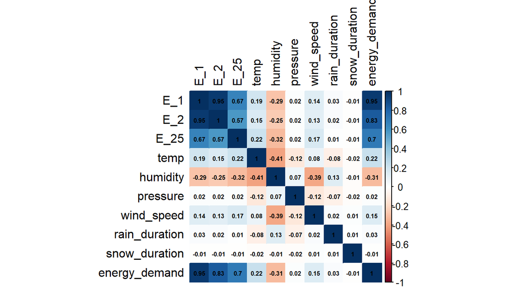

```r
corrplot(cor(workcor), method="color", type="full", addCoef.col = "black", tl.col="black",number.cex = 0.5)
```

```r
workModelValencia1 <- lm(energy_demand ~ E_1 + E_2 + E_25 + temp + humidity + pressure + wind_speed + rain_duration + snow_duration + factor(day_night) + factor(time_band) + factor(season) + factor(weather_main), data = workValencia)
```

```r
vif(workModelValencia1)
```

```
##                           GVIF Df GVIF^(1/(2*Df))
## E_1                  14.171607  1        3.764520
## E_2                  12.017128  1        3.466573
## E_25                  2.156342  1        1.468449
## temp                  3.403566  1        1.844876
## humidity              1.994951  1        1.412427
## pressure              1.139913  1        1.067667
## wind_speed            1.331132  1        1.153747
## rain_duration         1.456960  1        1.207046
## snow_duration         1.011179  1        1.005574
## factor(day_night)     1.965917  1        1.402112
## factor(time_band)     1.111991  2        1.026893
## factor(season)        3.270467  3        1.218339
## factor(weather_main)  1.816528  8        1.038013
```

```r
workModelValenciaFull <- lm(energy_demand ~ E_1 + E_25 + temp + humidity + pressure + wind_speed + rain_duration + snow_duration + factor(day_night) + factor(time_band) + factor(season) + factor(weather_main), data = workValencia)
vif(workModelValenciaFull)
```

```
##                          GVIF Df GVIF^(1/(2*Df))
## E_1                  2.039961  1        1.428272
## E_25                 1.973528  1        1.404823
## temp                 3.339423  1        1.827409
## humidity             1.993134  1        1.411784
## pressure             1.139889  1        1.067656
## wind_speed           1.329233  1        1.152924
## rain_duration        1.456598  1        1.206896
## snow_duration        1.011170  1        1.005569
## factor(day_night)    1.889044  1        1.374425
## factor(time_band)    1.108226  2        1.026023
## factor(season)       3.226785  3        1.215612
## factor(weather_main) 1.813697  8        1.037911
```

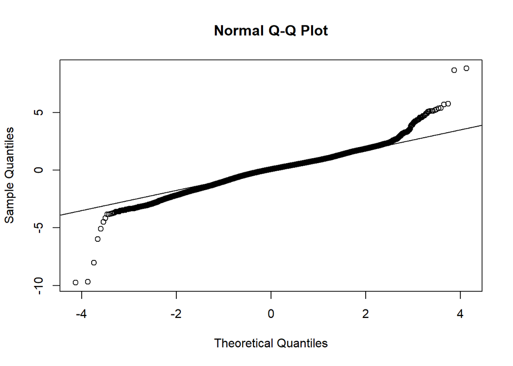

```r
# to obtain residuals
res.fullmodel1 <- residuals(workModelValenciaFull)
# to obtain standardized residuals
std.res.fullmodel1 <- rstandard(workModelValenciaFull)
# to obtain fitted/predicted values
pred.fullmodel1 <- fitted.values(workModelValenciaFull)
par(mfrow=c(1,1))
qqnorm(y = std.res.fullmodel1, main = " Normal Q-Q Plot ",
       xlab = "Theoretical Quantiles", ylab = "Sample Quantiles")
qqline(y = std.res.fullmodel1)
```

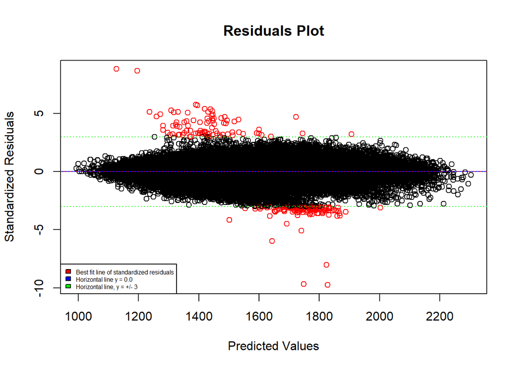

```r
#residual plot
resplotdata1 <- data.frame(std.res.fullmodel1, pred.fullmodel1)
resbf1 <- lm(std.res.fullmodel1 ~ pred.fullmodel1, data = resplotdata1)
plot(x = pred.fullmodel1, y = std.res.fullmodel1, ylab = "Standardized Residuals", xlab = "Predicted Values", main = "Residuals Plot", col = ifelse(std.res.fullmodel1 < -3,"red",ifelse(std.res.fullmodel1 > 3,"red","black")))
abline(h = 0, col="blue", lty=1)
abline(resbf1, col="red", lty=3)
abline(h = 3, col="green", lty=3)
abline(h=-3, col="green", lty=3)
legend("bottomleft", legend=c("Best fit line of standardized residuals", "Horizontal line y = 0.0", "Horizontal line, y = +/- 3"), fill = c("red","blue","green"), cex = 0.5)
```

```r
summary(workModelValenciaFull)
```

```
##
## Call:
## lm(formula = energy_demand ~ E_1 + E_25 + temp + humidity + pressure +
##     wind_speed + rain_duration + snow_duration + factor(day_night) +
##     factor(time_band) + factor(season) + factor(weather_main),
##     data = workValencia)
##
## Residuals:
##     Min      1Q  Median      3Q     Max
## -714.78  -41.44    6.33   45.09  647.09
##
## Coefficients:
##                            Estimate   Std. Error t value             Pr(>|t|)
## (Intercept)            -1003.690971    56.667174 -17.712 < 0.0000000000000002
## E_1                        0.884855     0.002462 359.354 < 0.0000000000000002
## E_25                       0.118354     0.002424  48.819 < 0.0000000000000002
## temp                       3.036519     0.111534  27.225 < 0.0000000000000002
## humidity                  -0.325270     0.031569 -10.303 < 0.0000000000000002
## pressure                   0.123376     0.046657   2.644              0.00819
## wind_speed                -0.852805     0.194388  -4.387  0.00001152758427349
## rain_duration              6.035686     1.965320   3.071              0.00213
## snow_duration            -48.622588    51.418802  -0.946              0.34435
## factor(day_night)2        34.469671     1.211297  28.457 < 0.0000000000000002
## factor(time_band)2         2.754287     6.014925   0.458              0.64702
## factor(time_band)3        44.964025     4.505279   9.980 < 0.0000000000000002
## factor(season)2          -26.939800     1.654365 -16.284 < 0.0000000000000002
## factor(season)3          -10.371166     1.345340  -7.709  0.00000000000001311
## factor(season)4            9.712012     1.440856   6.740  0.00000000001610023
## factor(weather_main)2      4.982183     0.968803   5.143  0.00000027278240873
## factor(weather_main)3     26.571095    11.630332   2.285              0.02234
## factor(weather_main)5     -3.902488    12.443279  -0.314              0.75381
## factor(weather_main)6     28.645610    51.837893   0.553              0.58054
## factor(weather_main)7     15.461673     6.125109   2.524              0.01160
## factor(weather_main)8     20.305312     2.564494   7.918  0.00000000000000251
## factor(weather_main)9     83.961927    32.799314   2.560              0.01048
## factor(weather_main)12    12.036941     7.374031   1.632              0.10262
##
## (Intercept)            ***
## E_1                    ***
## E_25                   ***
```

[output cut: 11 more lines]

```
## factor(season)4        ***
## factor(weather_main)2  ***
## factor(weather_main)3  *
## factor(weather_main)5
## factor(weather_main)6
## factor(weather_main)7  *
## factor(weather_main)8  ***
## factor(weather_main)9  *
## factor(weather_main)12
## ---
## Signif. codes:  0 '***' 0.001 '**' 0.01 '*' 0.05 '.' 0.1 ' ' 1
##
## Residual standard error: 73.29 on 27682 degrees of freedom
## Multiple R-squared:  0.9178, Adjusted R-squared:  0.9177
## F-statistic: 1.404e+04 on 22 and 27682 DF,  p-value: < 0.00000000000000022
```

```r
df<- workModelValenciaFull %>%
  tidy()
#Get the variables which there p-value larger than 0.05
df%>%
  filter(df$p.value>0.05)
```

| term | estimate | std.error | statistic | p.value |
| --- | --- | --- | --- | --- |
| snow_duration | -48.622588 | 51.418802 | -0.9456188 | 0.3443513 |
| factor(time_band)2 | 2.754287 | 6.014925 | 0.4579088 | 0.6470216 |
| factor(weather_main)5 | -3.902488 | 12.443279 | -0.3136221 | 0.7538104 |
| factor(weather_main)6 | 28.645610 | 51.837893 | 0.5525998 | 0.5805419 |
| factor(weather_main)12 | 12.036941 | 7.374031 | 1.6323421 | 0.1026188 |

```r
workModelValenciaPvalue <- lm(energy_demand ~ E_1 + E_25 + temp + humidity + pressure + wind_speed + rain_duration + factor(day_night) + factor(time_band) + factor(season) + factor(weather_main), data = workValencia)
summary(workModelValenciaPvalue)
```

```
##
## Call:
## lm(formula = energy_demand ~ E_1 + E_25 + temp + humidity + pressure +
##     wind_speed + rain_duration + factor(day_night) + factor(time_band) +
##     factor(season) + factor(weather_main), data = workValencia)
##
## Residuals:
##     Min      1Q  Median      3Q     Max
## -714.80  -41.47    6.31   45.11  647.11
##
## Coefficients:
##                            Estimate   Std. Error t value             Pr(>|t|)
## (Intercept)            -1004.925992    56.652013 -17.739 < 0.0000000000000002
## E_1                        0.884894     0.002462 359.422 < 0.0000000000000002
## E_25                       0.118386     0.002424  48.837 < 0.0000000000000002
## temp                       3.038226     0.111519  27.244 < 0.0000000000000002
## humidity                  -0.324448     0.031557 -10.281 < 0.0000000000000002
## pressure                   0.123945     0.046653   2.657              0.00789
## wind_speed                -0.850685     0.194374  -4.377   0.0000121024974039
## rain_duration              6.061477     1.965127   3.085              0.00204
## factor(day_night)2        34.492451     1.211055  28.481 < 0.0000000000000002
## factor(time_band)2         2.569012     6.011721   0.427              0.66914
## factor(time_band)3        44.633275     4.491673   9.937 < 0.0000000000000002
## factor(season)2          -26.966190     1.654127 -16.302 < 0.0000000000000002
## factor(season)3          -10.388206     1.345217  -7.722   0.0000000000000118
## factor(season)4            9.698814     1.440786   6.732   0.0000000000171069
## factor(weather_main)2      4.975234     0.968773   5.136   0.0000002831463489
## factor(weather_main)3     26.556133    11.630299   2.283              0.02242
## factor(weather_main)5     -3.927628    12.443227  -0.316              0.75228
## factor(weather_main)6     28.642884    51.837794   0.553              0.58058
## factor(weather_main)7     15.438547     6.125048   2.521              0.01172
## factor(weather_main)8     20.197124     2.561935   7.884   0.0000000000000033
## factor(weather_main)9     83.939146    32.799242   2.559              0.01050
## factor(weather_main)12    12.012127     7.373970   1.629              0.10333
##
## (Intercept)            ***
## E_1                    ***
## E_25                   ***
## temp                   ***
## humidity               ***
```

[output cut: 8 more lines]

```
## factor(season)4        ***
## factor(weather_main)2  ***
## factor(weather_main)3  *
## factor(weather_main)5
## factor(weather_main)6
## factor(weather_main)7  *
## factor(weather_main)8  ***
## factor(weather_main)9  *
## factor(weather_main)12
## ---
## Signif. codes:  0 '***' 0.001 '**' 0.01 '*' 0.05 '.' 0.1 ' ' 1
##
## Residual standard error: 73.29 on 27683 degrees of freedom
## Multiple R-squared:  0.9178, Adjusted R-squared:  0.9177
## F-statistic: 1.471e+04 on 21 and 27683 DF,  p-value: < 0.00000000000000022
```

- p-value approach

```r
anova(workModelValenciaPvalue, workModelValenciaFull)
```

|  | Res.Df | RSS | Df | Sum of Sq | F | Pr(>F) |
| --- | --- | --- | --- | --- | --- | --- |
| 1 | 27683 | 148683378 | NA | NA | NA | NA |
| 2 | 27682 | 148678576 | 1 | 4802.675 | 0.894195 | 0.3443513 |

- Best subset selection method

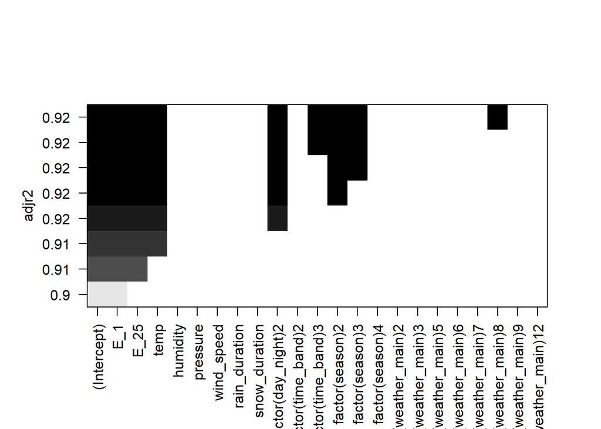

```r
bestfits <- regsubsets(energy_demand ~ E_1 + E_25 + temp + humidity + pressure + wind_speed + rain_duration + snow_duration + factor(day_night) + factor(time_band) + factor(season) + factor(weather_main), data = workValencia, nbest = 1)
plot(bestfits, scale="adjr2")
```

```r
workModelValenciaBestfit<-lm(energy_demand ~ E_1 + E_25 + temp + factor(day_night) + factor(time_band) + factor(season) + factor(weather_main), data = workValencia)
summary(workModelValenciaBestfit)
```

```
##
## Call:
## lm(formula = energy_demand ~ E_1 + E_25 + temp + factor(day_night) +
##     factor(time_band) + factor(season) + factor(weather_main),
##     data = workValencia)
##
## Residuals:
##     Min      1Q  Median      3Q     Max
## -713.54  -41.68    6.32   45.48  645.50
##
## Coefficients:
##                            Estimate   Std. Error t value             Pr(>|t|)
## (Intercept)            -1026.388603    29.108302 -35.261 < 0.0000000000000002
## E_1                        0.885725     0.002466 359.232 < 0.0000000000000002
## E_25                       0.120298     0.002420  49.719 < 0.0000000000000002
## temp                       3.465467     0.100419  34.510 < 0.0000000000000002
## factor(day_night)2        32.134863     1.187753  27.055 < 0.0000000000000002
## factor(time_band)2         0.989703     6.007040   0.165              0.86914
## factor(time_band)3        43.479302     4.476508   9.713 < 0.0000000000000002
## factor(season)2          -31.757105     1.552625 -20.454 < 0.0000000000000002
## factor(season)3          -13.493634     1.286982 -10.485 < 0.0000000000000002
## factor(season)4           10.088154     1.382228   7.298 0.000000000000298884
## factor(weather_main)2      2.443658     0.936693   2.609              0.00909
## factor(weather_main)3     20.134668    11.638553   1.730              0.08364
## factor(weather_main)5    -11.784953    12.439785  -0.947              0.34346
## factor(weather_main)6     26.107025    51.946095   0.503              0.61526
## factor(weather_main)7      8.294013     6.087548   1.362              0.17307
## factor(weather_main)8     17.024099     2.091205   8.141 0.000000000000000409
## factor(weather_main)9     84.584591    32.867921   2.573              0.01007
## factor(weather_main)12     4.984582     7.346590   0.678              0.49747
##
## (Intercept)            ***
## E_1                    ***
## E_25                   ***
## temp                   ***
## factor(day_night)2     ***
## factor(time_band)2
## factor(time_band)3     ***
## factor(season)2        ***
## factor(season)3        ***
## factor(season)4        ***
## factor(weather_main)2  **
## factor(weather_main)3  .
## factor(weather_main)5
## factor(weather_main)6
## factor(weather_main)7
## factor(weather_main)8  ***
## factor(weather_main)9  *
## factor(weather_main)12
## ---
## Signif. codes:  0 '***' 0.001 '**' 0.01 '*' 0.05 '.' 0.1 ' ' 1
##
## Residual standard error: 73.44 on 27687 degrees of freedom
## Multiple R-squared:  0.9174, Adjusted R-squared:  0.9174
## F-statistic: 1.809e+04 on 17 and 27687 DF,  p-value: < 0.00000000000000022
```

```r
anova(workModelValenciaBestfit, workModelValenciaPvalue)
```

|  | Res.Df | RSS | Df | Sum of Sq | F | Pr(>F) |
| --- | --- | --- | --- | --- | --- | --- |
| 1 | 27687 | 149330620 | NA | NA | NA | NA |
| 2 | 27683 | 148683378 | 4 | 647241.8 | 30.1271 | 0.0000000000000000000000004720699 |

- AIC with forward selection approach test method

```r
workNullModel<- lm(energy_demand ~ 1, data = workValencia)
step.working <- stepAIC(workNullModel, scope = list(lower = workNullModel,
upper = workModelValenciaFull), direction = "forward", trace=FALSE)
summary(step.working)
```

```
##
## Call:
## lm(formula = energy_demand ~ E_1 + E_25 + temp + factor(day_night) +
##     factor(season) + factor(time_band) + factor(weather_main) +
##     humidity + wind_speed + rain_duration + pressure, data = workValencia)
##
## Residuals:
##     Min      1Q  Median      3Q     Max
## -714.80  -41.47    6.31   45.11  647.11
##
## Coefficients:
##                            Estimate   Std. Error t value             Pr(>|t|)
## (Intercept)            -1004.925992    56.652013 -17.739 < 0.0000000000000002
## E_1                        0.884894     0.002462 359.422 < 0.0000000000000002
## E_25                       0.118386     0.002424  48.837 < 0.0000000000000002
## temp                       3.038226     0.111519  27.244 < 0.0000000000000002
## factor(day_night)2        34.492451     1.211055  28.481 < 0.0000000000000002
## factor(season)2          -26.966190     1.654127 -16.302 < 0.0000000000000002
## factor(season)3          -10.388206     1.345217  -7.722   0.0000000000000118
## factor(season)4            9.698814     1.440786   6.732   0.0000000000171069
## factor(time_band)2         2.569012     6.011721   0.427              0.66914
## factor(time_band)3        44.633275     4.491673   9.937 < 0.0000000000000002
## factor(weather_main)2      4.975234     0.968773   5.136   0.0000002831463489
## factor(weather_main)3     26.556133    11.630299   2.283              0.02242
## factor(weather_main)5     -3.927628    12.443227  -0.316              0.75228
## factor(weather_main)6     28.642884    51.837794   0.553              0.58058
## factor(weather_main)7     15.438547     6.125048   2.521              0.01172
## factor(weather_main)8     20.197124     2.561935   7.884   0.0000000000000033
## factor(weather_main)9     83.939146    32.799242   2.559              0.01050
## factor(weather_main)12    12.012127     7.373970   1.629              0.10333
## humidity                  -0.324448     0.031557 -10.281 < 0.0000000000000002
## wind_speed                -0.850685     0.194374  -4.377   0.0000121024974039
## rain_duration              6.061477     1.965127   3.085              0.00204
## pressure                   0.123945     0.046653   2.657              0.00789
##
## (Intercept)            ***
## E_1                    ***
## E_25                   ***
## temp                   ***
## factor(day_night)2     ***
```

[output cut: 8 more lines]

```
## factor(weather_main)6
## factor(weather_main)7  *
## factor(weather_main)8  ***
## factor(weather_main)9  *
## factor(weather_main)12
## humidity               ***
## wind_speed             ***
## rain_duration          **
## pressure               **
## ---
## Signif. codes:  0 '***' 0.001 '**' 0.01 '*' 0.05 '.' 0.1 ' ' 1
##
## Residual standard error: 73.29 on 27683 degrees of freedom
## Multiple R-squared:  0.9178, Adjusted R-squared:  0.9177
## F-statistic: 1.471e+04 on 21 and 27683 DF,  p-value: < 0.00000000000000022
```

- Cross Validation test method

```r
# Set seed for reproducibility in CV
set.seed(123)
# Set up repeated k-fold cross-validation, with k=10
train.control <- trainControl(method = "cv", number = 10)
# Train the model
step.cv.work <- train(energy_demand ~ E_1 + E_25 + temp + humidity + pressure + wind_speed + rain_duration + snow_duration + factor(day_night) + factor(time_band) + factor(season) + factor(weather_main), data = workValencia, method = "leapBackward",
tuneGrid = data.frame(nvmax = 1:12),
trControl = train.control)
step.cv.work$results
```

|  | nvmax | RMSE | Rsquared | MAE | RMSESD | RsquaredSD | MAESD |
| --- | --- | --- | --- | --- | --- | --- | --- |
| 1 | 1 | 78.85864 | 0.9047285 | 59.08331 | 1.721547 | 0.004338635 | 0.9239500 |
| 2 | 2 | 75.55001 | 0.9125411 | 57.78791 | 1.691626 | 0.004145045 | 0.9735625 |
| 3 | 3 | 75.18144 | 0.9133951 | 57.36447 | 1.720223 | 0.004160394 | 1.0480571 |
| 4 | 4 | 74.39665 | 0.9151895 | 56.83599 | 1.746246 | 0.004132705 | 1.0182011 |
| 5 | 5 | 74.00804 | 0.9160689 | 56.39143 | 1.781067 | 0.004132095 | 1.0334161 |
| 6 | 6 | 73.72845 | 0.9167084 | 56.12588 | 1.726186 | 0.004023012 | 1.0052268 |
| 7 | 7 | 73.58561 | 0.9170336 | 56.06495 | 1.705203 | 0.003978149 | 1.0020839 |
| 8 | 8 | 73.54194 | 0.9171300 | 56.01531 | 1.750650 | 0.004083460 | 1.0412486 |
| 9 | 9 | 73.43220 | 0.9173782 | 55.88535 | 1.777272 | 0.004140544 | 1.0437187 |
| 10 | 10 | 73.36574 | 0.9175288 | 55.79521 | 1.771839 | 0.004111462 | 1.0547762 |

[output cut: 2 more lines]

```r
summary(step.cv.work$finalModel)
```

```
## Subset selection object
## 22 Variables  (and intercept)
##                        Forced in Forced out
## E_1                        FALSE      FALSE
## E_25                       FALSE      FALSE
## temp                       FALSE      FALSE
## humidity                   FALSE      FALSE
## pressure                   FALSE      FALSE
## wind_speed                 FALSE      FALSE
## rain_duration              FALSE      FALSE
## snow_duration              FALSE      FALSE
## factor(day_night)2         FALSE      FALSE
## factor(time_band)2         FALSE      FALSE
## factor(time_band)3         FALSE      FALSE
## factor(season)2            FALSE      FALSE
```

[output cut: 90 more lines]

```r
workModelValenciaCross <- lm(energy_demand ~ E_1 + E_25 + temp + humidity + factor(day_night) + factor(time_band) + factor(season) + factor(weather_main), data = workValencia)
anova( workModelValenciaCross, workModelValenciaPvalue)
```

|  | Res.Df | RSS | Df | Sum of Sq | F | Pr(>F) |
| --- | --- | --- | --- | --- | --- | --- |
| 1 | 27686 | 148890185 | NA | NA | NA | NA |
| 2 | 27683 | 148683378 | 3 | 206806.6 | 12.83494 | 0.00000002238046 |

```r
summary(workModelValenciaCross)
```

```
##
## Call:
## lm(formula = energy_demand ~ E_1 + E_25 + temp + humidity + factor(day_night) +
##     factor(time_band) + factor(season) + factor(weather_main),
##     data = workValencia)
##
## Residuals:
##     Min      1Q  Median      3Q     Max
## -711.96  -41.22    6.24   45.23  645.94
##
## Coefficients:
##                           Estimate  Std. Error t value             Pr(>|t|)
## (Intercept)            -881.560408   33.180368 -26.569 < 0.0000000000000002 ***
## E_1                       0.885344    0.002462 359.549 < 0.0000000000000002 ***
## E_25                      0.118381    0.002425  48.811 < 0.0000000000000002 ***
## temp                      3.025870    0.111419  27.158 < 0.0000000000000002 ***
## humidity                 -0.269465    0.029776  -9.050 < 0.0000000000000002 ***
## factor(day_night)2       34.378128    1.211648  28.373 < 0.0000000000000002 ***
## factor(time_band)2        0.123778    5.999046   0.021               0.9835
## factor(time_band)3       42.172498    4.472314   9.430 < 0.0000000000000002 ***
## factor(season)2         -26.574433    1.652752 -16.079 < 0.0000000000000002 ***
## factor(season)3         -10.019958    1.341205  -7.471    0.000000000000082 ***
## factor(season)4           9.681355    1.380945   7.011    0.000000000002426 ***
## factor(weather_main)2     4.007721    0.951161   4.214    0.000025223409140 ***
## factor(weather_main)3    24.594350   11.632030   2.114               0.0345 *
## factor(weather_main)5    -4.027791   12.451190  -0.323               0.7463
## factor(weather_main)6    28.171788   51.870872   0.543               0.5871
## factor(weather_main)7    15.305422    6.127849   2.498               0.0125 *
## factor(weather_main)8    21.905840    2.156707  10.157 < 0.0000000000000002 ***
## factor(weather_main)9    84.119876   32.820047   2.563               0.0104 *
## factor(weather_main)12   10.464185    7.360827   1.422               0.1552
## ---
## Signif. codes:  0 '***' 0.001 '**' 0.01 '*' 0.05 '.' 0.1 ' ' 1
##
## Residual standard error: 73.33 on 27686 degrees of freedom
## Multiple R-squared:  0.9176, Adjusted R-squared:  0.9176
## F-statistic: 1.714e+04 on 18 and 27686 DF,  p-value: < 0.00000000000000022
```

## Select the final model

Model adjusted R-square from above methods

1. P-value: 0.9177
2. Bestfits: 0.9174
3. AIC Method: 0.9177
4. Cross-validation: 0.9176

Final model is the workModelValenciaPvalue with highest Adjusted R-square.

### Build the Final Model

```r
workFinal <- workModelValenciaPvalue
```

### Check the linearity, heteroscedasticity, outlier and normal assumption

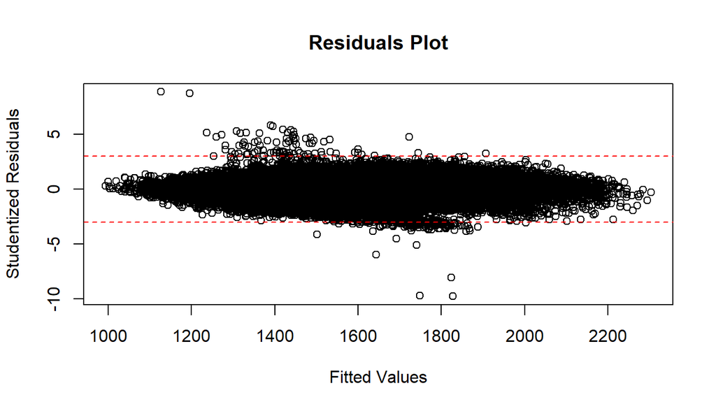

```r
par(mfrow=c(1,1))
#Residual Plot
plot(x=fitted(workFinal), y=studres(workFinal), xlab = "Fitted Values",
ylab = "Studentized Residuals", main='Residuals Plot')
abline(h=-3, col="red", lty=2)
abline(h=3, col="red", lty=2)
```

```r
#norm test
std.res <- rstandard(workFinal)
ad.test(std.res)
```

```
##
##  Anderson-Darling normality test
##
## data:  std.res
## A = 118.51, p-value < 0.00000000000000022
```

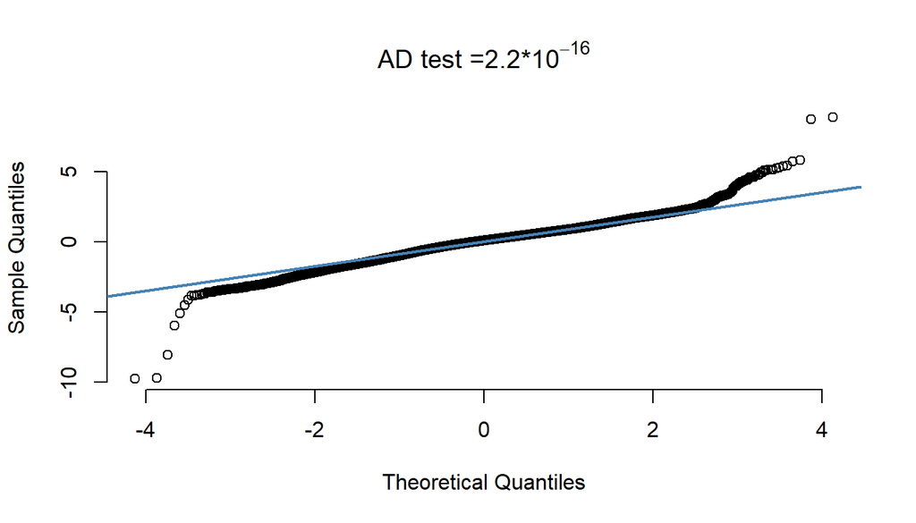

```r
qqnorm(studres(workFinal), pch = 1, frame = FALSE, main=expression("AD test =2.2*10"^-16))
qqline(studres(workFinal), col = "steelblue", lwd = 2)
```

```r
#leverage
lev<-hatvalues(workFinal)
cutlev = (2*length(coefficients(workFinal)))/nrow(workValencia)
# Count and assess the number of leverage values > cut-off
potoutlier <- sum(lev > cutlev, na.rm=TRUE)
totcount = length(fitted(workFinal))
print(paste("The number of leverage points that are potential outliers is", potoutlier,".  This is", round(100*potoutlier/totcount,2),"% of the total number of predicted values, (", totcount,") thus not material."))
```

```
## [1] "The number of leverage points that are potential outliers is 936 .  This is 3.38 % of the total number of predicted values, ( 27705 ) thus not material."
```

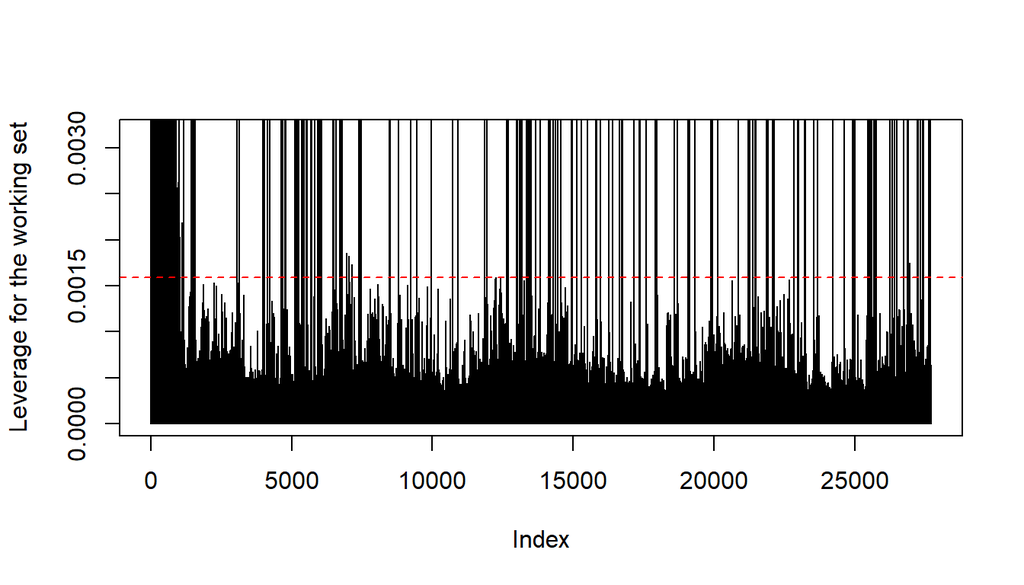

```r
#barplot(lev, ylim = c(0, 2*cutlev))
plot(lev, type="h", ylim = c(0, 2*cutlev), ylab="Leverage for the working set")
abline(h = cutlev, col = "red", lty=2)
```

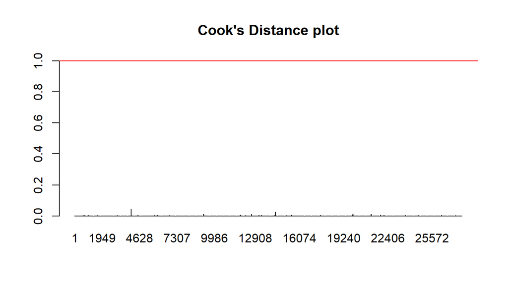

```r
#cook distance
cookdist<-cooks.distance(workFinal)
barplot(cookdist, ylim=c(0,1.01), main = "Cook's Distance plot")
abline(h = 1, col = "red")
```

### Use the estimated model to predict the values in the evaluation set

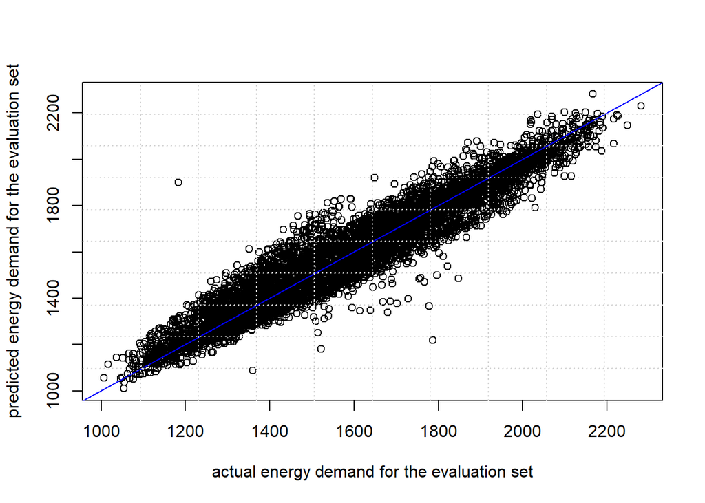

```r
newdata <- evalValencia[ c(-2,-14)]
predict.eval <- predict(workFinal, newdata)
plot(x = evalValencia$energy_demand, y=predict.eval, xlab="actual energy demand for the evaluation set",
ylab="predicted energy demand for the evaluation set")
abline(a=0, b=1, col="blue")
grid(10,10)
```

### Compute the RMSE for the predictions

```r
rootmse <- rmse(evalValencia$energy_demand, predict.eval)
print(paste("The root mean square error of the predicted vs actual",nrow(evalValencia),"hourly energy_data points for Valencia over the 2015-2018 timespan is an energy demand difference of",round(rootmse,2),"kW (assumed unit of measure)."))
```

```
## [1] "The root mean square error of the predicted vs actual 6927 hourly energy_data points for Valencia over the 2015-2018 timespan is an energy demand difference of 73.9 kW (assumed unit of measure)."
```

```r
diffpct <- c((abs(evalValencia$energy_demand - predict.eval))/evalValencia$energy_demand)
print(paste("The mean difference between the",nrow(evalValencia),"evaluation data set actual and model predicted values is",round(100*mean(diffpct),2),"%."))
```

```
## [1] "The mean difference between the 6927 evaluation data set actual and model predicted values is 3.6 %."
```